# EDA Quiz

```python
import numpy as np
import pandas as pd
import matplotlib.pyplot as plt
import seaborn as sns
```

```python
import os
os.chdir("D:\\Academic Operations\\DSBA - Python\\Online\\Advanced Statistics\\EDA\\Quiz Dataset\\2")
os.getcwd()
```

```
'D:\\Academic Operations\\DSBA - Python\\Online\\Advanced Statistics\\EDA\\Quiz Dataset\\2'
```

```python
df = pd.read_csv("Slump Test.csv")
```

```python
df.head()
```

|  | Cement | Slag | Fly ash | Water | SP | Coarse | Fine | SLUMP | FLOW | Strength |
| --- | --- | --- | --- | --- | --- | --- | --- | --- | --- | --- |
| 0 | 273.0 | 82.0 | 105.0 | 210.0 | 9.0 | 904.0 | 680.0 | 23.0 | 62.0 | 34.99 |
| 1 | 163.0 | 149.0 | 191.0 | 180.0 | 12.0 | 843.0 | 746.0 | 0.0 | 20.0 | 41.14 |
| 2 | 162.0 | 148.0 | 191.0 | 179.0 | 16.0 | 840.0 | 743.0 | 1.0 | 20.0 | 41.81 |
| 3 | 162.0 | 148.0 | 190.0 | 179.0 | 19.0 | 838.0 | 741.0 | 3.0 | 21.5 | 42.08 |
| 4 | 154.0 | 112.0 | 144.0 | 220.0 | 10.0 | 923.0 | 658.0 | 20.0 | 64.0 | 26.82 |

# 1) How many modes are present in the variable 'Strength' of the dataset?

```python
print(df['Strength'].mode().count())
```

```
20
```

# 2) What is the mean of the variable 'Water' in the dataset?

```python
df.describe(include="all")
```

|  | Cement | Slag | Fly ash | Water | SP | Coarse | Fine | SLUMP | FLOW | Strength |
| --- | --- | --- | --- | --- | --- | --- | --- | --- | --- | --- |
| count | 103.000000 | 103.000000 | 103.000000 | 103.000000 | 103.000000 | 103.000000 | 103.000000 | 103.000000 | 103.00000 | 103.000000 |
| mean | 229.894175 | 77.973786 | 149.014563 | 197.167961 | 8.539806 | 883.978641 | 739.604854 | 18.048544 | 49.61068 | 36.039417 |
| std | 78.877230 | 60.461363 | 85.418080 | 20.208158 | 2.807530 | 88.391393 | 63.342117 | 8.750844 | 17.56861 | 7.838232 |
| min | 137.000000 | 0.000000 | 0.000000 | 160.000000 | 4.400000 | 708.000000 | 640.600000 | 0.000000 | 20.00000 | 17.190000 |
| 25% | 152.000000 | 0.050000 | 115.500000 | 180.000000 | 6.000000 | 819.500000 | 684.500000 | 14.500000 | 38.50000 | 30.900000 |
| 50% | 248.000000 | 100.000000 | 164.000000 | 196.000000 | 8.000000 | 879.000000 | 742.700000 | 21.500000 | 54.00000 | 35.520000 |
| 75% | 303.900000 | 125.000000 | 235.950000 | 209.500000 | 10.000000 | 952.800000 | 788.000000 | 24.000000 | 63.75000 | 41.205000 |
| max | 374.000000 | 193.000000 | 260.000000 | 240.000000 | 19.000000 | 1049.900000 | 902.000000 | 29.000000 | 78.00000 | 58.530000 |

```python
df['Water'].mean()
```

```
197.16796116504858
```

# 3) Following is a histogram plot of the variable 'Fly ash' with its mean,median and mode. Match the correct measure of central tendency with the correct colour.

```python
print(df['Fly ash'].mode().count())
```

```
1
```

```
Mean:  149.0145631067961
Median:  164.0
Mode:  0.0
```

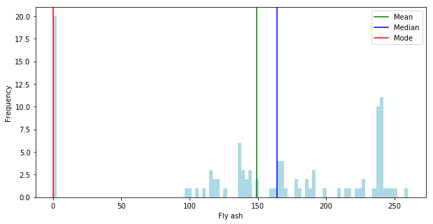

```python
mean=df['Fly ash'].mean()
median=df['Fly ash'].median()
mode=df['Fly ash'].mode()

print('Mean: ',mean,'\nMedian: ',median,'\nMode: ',mode[0])

plt.figure(figsize=(10,5)) # set the figure size
plt.hist(df['Fly ash'],bins=100,color='lightblue') #Plot the histogram

plt.axvline(mean,color='green',label='Mean')     # Draw lines on the plot for mean median and the two modes we have in GRE Score
plt.axvline(median,color='blue',label='Median')
plt.axvline(mode[0],color='red',label='Mode')

plt.xlabel('Fly ash')   # label the x-axis
plt.ylabel('Frequency')   # label the y-axis
plt.legend()              # Plot the legend
plt.show()
```

Green – Mean, Blue – Median, Red – Mode

# 4) The covariance between the variables ‘Cement’ and ‘Slag’ is same as the covariance between the variables ‘Slag’ and ‘Cement.

# True or False?

```python
df.cov()
```

|  | Cement | Slag | Fly ash | Water | SP | Coarse | Fine | SLUMP | FLOW | Strength |
| --- | --- | --- | --- | --- | --- | --- | --- | --- | --- | --- |
| Cement | 6221.617417 | -1161.508095 | -3278.051679 | 352.411380 | -23.559374 | -2160.342969 | 284.580813 | 100.714991 | 258.390259 | 275.572938 |
| Slag | -1161.508095 | 3655.576463 | -1666.164124 | -32.713593 | 52.028211 | -1196.005958 | -702.843499 | -150.280333 | -347.591678 | -157.142937 |
| Fly ash | -3278.051679 | -1666.164124 | 7296.248315 | -416.553646 | -34.415193 | 1303.319236 | -1530.400660 | -88.667135 | -83.172706 | 297.532714 |
| Water | 352.411380 | -32.713593 | -416.553646 | 408.369650 | -8.819791 | -1075.668338 | 146.679569 | 82.507208 | 224.387600 | -40.269862 |
| SP | -23.559374 | 52.028211 | -34.415193 | -8.819791 | 7.882223 | -25.848357 | 10.366079 | -5.230628 | -8.696606 | -0.833388 |
| Coarse | -2160.342969 | -1196.005958 | 1303.319236 | -1075.668338 | -25.848357 | 7813.038363 | -2735.267542 | -145.539394 | -505.918691 | -111.327013 |
| Fine | 284.580813 | -702.843499 | -1530.400660 | 146.679569 | 10.366079 | -2735.267542 | 4012.223800 | 112.118880 | 211.849555 | -76.699948 |
| SLUMP | 100.714991 | -150.280333 | -88.667135 | 82.507208 | -5.230628 | -145.539394 | 112.118880 | 76.577277 | 139.309280 | -15.320388 |
| FLOW | 258.390259 | -347.591678 | -83.172706 | 224.387600 | -8.696606 | -505.918691 | 211.849555 | 139.309280 | 308.656061 | -17.079700 |
| Strength | 275.572938 | -157.142937 | 297.532714 | -40.269862 | -0.833388 | -111.327013 | -76.699948 | -15.320388 | -17.079700 | 61.437878 |

From the above covariance table we see that the covariance between the variables 'Cement' and 'Slag' is -1161.508 and the covariance between the variables 'Slag' and 'Cement' is also -1161.508. Both are same. Hence, the answer is $\textbf{TRUE}$.

# 5) What is the correlation coefficient between the variables ‘Coarse’ and ‘Cement’?

```python
df.corr()
```

|  | Cement | Slag | Fly ash | Water | SP | Coarse | Fine | SLUMP | FLOW | Strength |
| --- | --- | --- | --- | --- | --- | --- | --- | --- | --- | --- |
| Cement | 1.000000 | -0.243553 | -0.486535 | 0.221091 | -0.106387 | -0.309857 | 0.056959 | 0.145913 | 0.186461 | 0.445725 |
| Slag | -0.243553 | 1.000000 | -0.322619 | -0.026775 | 0.306504 | -0.223792 | -0.183522 | -0.284037 | -0.327231 | -0.331588 |
| Fly ash | -0.486535 | -0.322619 | 1.000000 | -0.241321 | -0.143508 | 0.172620 | -0.282854 | -0.118621 | -0.055423 | 0.444393 |
| Water | 0.221091 | -0.026775 | -0.241321 | 1.000000 | -0.155456 | -0.602201 | 0.114591 | 0.466568 | 0.632026 | -0.254235 |
| SP | -0.106387 | 0.306504 | -0.143508 | -0.155456 | 1.000000 | -0.104159 | 0.058290 | -0.212902 | -0.176314 | -0.037871 |
| Coarse | -0.309857 | -0.223792 | 0.172620 | -0.602201 | -0.104159 | 1.000000 | -0.488537 | -0.188157 | -0.325787 | -0.160684 |
| Fine | 0.056959 | -0.183522 | -0.282854 | 0.114591 | 0.058290 | -0.488537 | 1.000000 | 0.202272 | 0.190370 | -0.154484 |
| SLUMP | 0.145913 | -0.284037 | -0.118621 | 0.466568 | -0.212902 | -0.188157 | 0.202272 | 1.000000 | 0.906135 | -0.223358 |
| FLOW | 0.186461 | -0.327231 | -0.055423 | 0.632026 | -0.176314 | -0.325787 | 0.190370 | 0.906135 | 1.000000 | -0.124029 |
| Strength | 0.445725 | -0.331588 | 0.444393 | -0.254235 | -0.037871 | -0.160684 | -0.154484 | -0.223358 | -0.124029 | 1.000000 |

From the above table we see that the value of the correlation coefficient between the variables 'Coarse' and 'Cement' is $\textbf{-0.309857}$.

# 6) How many variables are negatively skewed in the given dataset?

```python
list = df.skew()
print (list)
```

```
Cement      0.145140
Slag       -0.193079
Fly ash    -0.680019
Water       0.263532
SP          1.125753
Coarse      0.121009
Fine        0.265958
SLUMP      -1.112837
FLOW       -0.520705
Strength    0.192235
dtype: float64
```

From the above list, we can count and see that there are 4 negatively skewed variables.

But, let us see how we can automate this counting process so that it becomes easier if we have a lot of variables

```python
#First, let us define two variables and initialise it to 0.
pos_count, neg_count = 0, 0

for num in list: #we are running a 'counter' variable in the 'list' variables defined in the previous cell

    # checking condition to see whether the numbers are positive or negative
    if num >= 0:
        pos_count += 1

    else:
        neg_count += 1

print("The number of negative numbers are", neg_count,".")
```

```
The number of negative numbers are 4 .
```

# 7) There are no missing values in the dataset.

# True or False?

```python
df.isnull().sum()
```

```
Cement      0
Slag        0
Fly ash     0
Water       0
SP          0
Coarse      0
Fine        0
SLUMP       0
FLOW        0
Strength    0
dtype: int64
```

From the above list we see that there are $\textbf{no missing values in the dataset}$. Thus, the answer is $\textbf{TRUE}$

# 8) How many duplicate values are present in the variable 'FLOW'?

```python
dupes = df['FLOW'].duplicated()
sum(dupes)
```

```
52
```

# 9) In this dataset, all the variables are not of "float64" type.

# True or False?

```python
df.dtypes.value_counts()
```

```
float64    10
dtype: int64
```

From the result of the above code snippet, we see that the answer is $\textbf{FALSE}$ as all the variables are of "float 64" type

# 10) Which of the following is the boxplot of the variable 'Strength'?

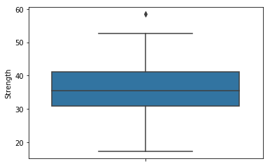

```python
sns.boxplot(df['Strength'],orient="v")
```

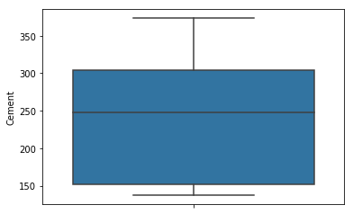

```python
sns.boxplot(df['Cement'],orient="v")
```

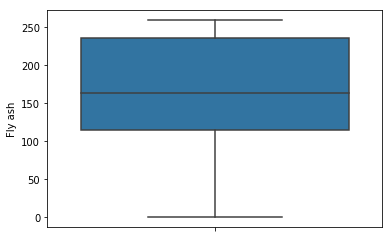

```python
sns.boxplot(df['Fly ash'],orient="v")
```

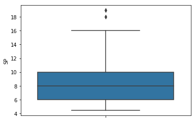

```python
sns.boxplot(df['SP'],orient="v")
```

# 11) There exists a relatively strong linear relationship between the variables 'FLOW' and 'SLUMP'.

# True or False?

```python
df.corr()
```

|  | Cement | Slag | Fly ash | Water | SP | Coarse | Fine | SLUMP | FLOW | Strength |
| --- | --- | --- | --- | --- | --- | --- | --- | --- | --- | --- |
| Cement | 1.000000 | -0.243553 | -0.486535 | 0.221091 | -0.106387 | -0.309857 | 0.056959 | 0.145913 | 0.186461 | 0.445725 |
| Slag | -0.243553 | 1.000000 | -0.322619 | -0.026775 | 0.306504 | -0.223792 | -0.183522 | -0.284037 | -0.327231 | -0.331588 |
| Fly ash | -0.486535 | -0.322619 | 1.000000 | -0.241321 | -0.143508 | 0.172620 | -0.282854 | -0.118621 | -0.055423 | 0.444393 |
| Water | 0.221091 | -0.026775 | -0.241321 | 1.000000 | -0.155456 | -0.602201 | 0.114591 | 0.466568 | 0.632026 | -0.254235 |
| SP | -0.106387 | 0.306504 | -0.143508 | -0.155456 | 1.000000 | -0.104159 | 0.058290 | -0.212902 | -0.176314 | -0.037871 |
| Coarse | -0.309857 | -0.223792 | 0.172620 | -0.602201 | -0.104159 | 1.000000 | -0.488537 | -0.188157 | -0.325787 | -0.160684 |
| Fine | 0.056959 | -0.183522 | -0.282854 | 0.114591 | 0.058290 | -0.488537 | 1.000000 | 0.202272 | 0.190370 | -0.154484 |
| SLUMP | 0.145913 | -0.284037 | -0.118621 | 0.466568 | -0.212902 | -0.188157 | 0.202272 | 1.000000 | 0.906135 | -0.223358 |
| FLOW | 0.186461 | -0.327231 | -0.055423 | 0.632026 | -0.176314 | -0.325787 | 0.190370 | 0.906135 | 1.000000 | -0.124029 |
| Strength | 0.445725 | -0.331588 | 0.444393 | -0.254235 | -0.037871 | -0.160684 | -0.154484 | -0.223358 | -0.124029 | 1.000000 |

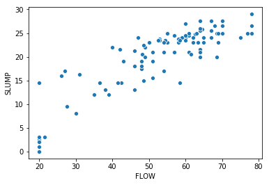

```python
sns.scatterplot(df['FLOW'],df['SLUMP'])
```

We can see from both the correlation coefficient and the scatterplot that there is $\textbf{indeed a linear relationship between the variable 'FLOW' and 'SLUMP'}$. Thus, the answer is $\textbf{TRUE}$.

# 12)The value of the 103rd row and the 2nd column is less than the threshold (threshold equal to 1) after doing z-score scaling.

# True or False?

```python
from scipy import stats
z = np.abs(stats.zscore(df))   # get the z-score of every value with respect to their columns
print(z)
```

```
[[0.54916499 0.06691714 0.51780366 ... 0.56859301 0.7086448  0.13453916]
 [0.85222678 1.18048168 0.49393227 ... 2.07257727 1.69367274 0.65391335]
 [0.8649667  1.16386132 0.49393227 ... 1.95774378 1.69367274 0.7398098 ]
 ...
 [0.36825805 0.16663934 1.06568072 ... 2.07257727 1.69367274 1.8538996 ]
 [0.85619718 0.61617991 1.06921003 ... 1.08534372 0.99463498 1.68338873]
 [1.51357732 1.29429085 0.87156859 ... 1.25759395 1.62381339 1.63210727]]
```

```python
threshold = 1
np.where(z > threshold)
```

```
(array([  1,   1,   1,   1,   2,   2,   2,   2,   3,   3,   3,   3,   4,
          4,   4,   5,   5,   5,   6,   6,   6,   6,   6,   7,   7,   7,
          7,   7,   8,   8,   8,   8,   9,  10,  10,  10,  10,  11,  11,
         11,  11,  12,  12,  12,  13,  13,  13,  13,  14,  14,  14,  14,
         15,  15,  16,  16,  16,  17,  17,  18,  18,  18,  18,  18,  19,
         19,  20,  21,  21,  21,  21,  21,  22,  22,  22,  22,  22,  22,
         22,  23,  23,  23,  23,  24,  24,  24,  24,  25,  25,  26,  26,
         27,  27,  28,  28,  29,  29,  30,  30,  30,  30,  31,  31,  31,
         31,  31,  31,  32,  32,  32,  33,  33,  33,  34,  34,  34,  34,
         34,  34,  35,  36,  37,  37,  37,  37,  37,  37,  38,  38,  38,
         38,  39,  39,  39,  40,  40,  40,  40,  40,  41,  41,  42,  43,
         43,  44,  44,  44,  44,  45,  45,  48,  48,  48,  48,  48,  48,
         48,  49,  49,  49,  49,  50,  50,  50,  51,  51,  51,  51,  52,
         52,  52,  52,  52,  53,  53,  53,  54,  54,  54,  55,  55,  55,
         55,  55,  56,  57,  57,  58,  58,  58,  58,  59,  59,  59,  60,
```

[output cut: 32 more lines]

**Note:** The first array contains the list of row numbers and second array respective column numbers.

```python
print(z[102][1])
```

```
1.2942908529114074
```

From the above results, we can see that the 103rd row and the 2nd column is greater than the threshold (threshold set to 1) after doing z-score scaling. Thus, the above statement is $\textbf{FALSE}$.

# 13) What is the Inter Quartile Range (IQR) of the variable ‘Fine’?

```python
Q1 = df.quantile(0.25)
Q3 = df.quantile(0.75)
IQR = Q3 - Q1
print(IQR)
```

```
Cement      151.900
Slag        124.950
Fly ash     120.450
Water        29.500
SP            4.000
Coarse      133.300
Fine        103.500
SLUMP         9.500
FLOW         25.250
Strength     10.305
dtype: float64
```

```python
print("The IQR of the variable 'fine' is",IQR[6],".")
```

```
The IQR of the variable 'fine' is 103.5 .
```

# 14) Which of the following is the frequency polygon of the variable 'Slag'?

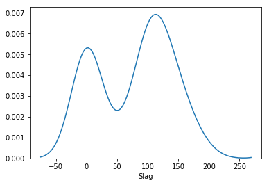

```python
sns.distplot(df['Slag'], hist=False)
```

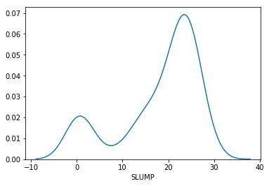

```python
sns.distplot(df['SLUMP'], hist=False)
```

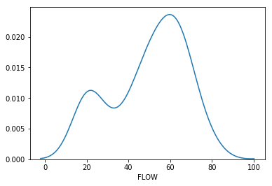

```python
sns.distplot(df['FLOW'], hist=False)
```

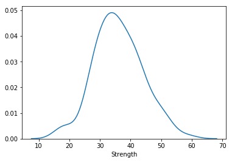

```python
sns.distplot(df['Strength'], hist=False)
```

# 15) Which of the following is the ogive curve for the variable 'Strength'?

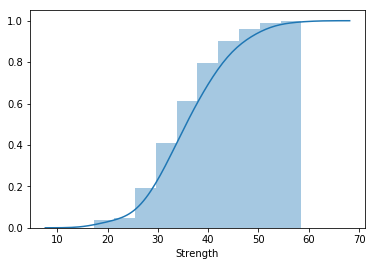

```python
sns.distplot(df['Strength'], hist_kws=dict(cumulative=True), kde_kws=dict(cumulative=True))
```

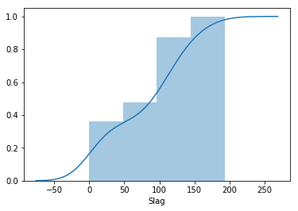

```python
sns.distplot(df['Slag'], hist_kws=dict(cumulative=True), kde_kws=dict(cumulative=True))
```

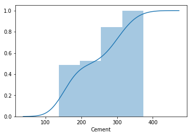

```python
sns.distplot(df['Cement'], hist_kws=dict(cumulative=True), kde_kws=dict(cumulative=True))
```

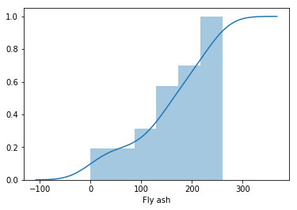

```python
sns.distplot(df['Fly ash'], hist_kws=dict(cumulative=True), kde_kws=dict(cumulative=True))
```